# Simulation exercise in **Genomik und Bioinformatik**

## Part D) Programming - Consensus clustering

**1. Have a look at the data to be clustered:**

```r
> library(vsn)
> library(affy)
> load(file= "C:/Users/aleX/Kurse/genomik/Blatt8/mmml_subset.rda")
>
> myExpr <- exprs(mmml.subset)
> str(myExpr) #22283 genes #50 samples
```

```
##  num [1:22283, 1:50] 9.13 8.86 8.02 9.85 6.86 ...
##  - attr(*, "dimnames")=List of 2
##   ..$ : chr [1:22283] "1007_s_at" "1053_at" "117_at" "121_at" ...
##   ..$ : chr [1:50] "MPI-002" "MPI-005" "MPI-008" "MPI-013" ...
```

```r
> variable <- apply(myExpr, 1, sd)
> N <- 500
> most_variable_index <- order(variable, decreasing=TRUE)[1:N]
> myData <- myExpr[most_variable_index,]
> str(myData)
```

```
##  num [1:500, 1:50] 13.72 7.08 9.96 13.04 12.35 ...
##  - attr(*, "dimnames")=List of 2
##   ..$ : chr [1:500] "202917_s_at" "210258_at" "213831_at" "209995_s_at" ...
##   ..$ : chr [1:50] "MPI-002" "MPI-005" "MPI-008" "MPI-013" ...
```

**2. Planning the implementation of consensus clustering with hclust:**

**Answer (2a):**  
**Parameter/ Typ:**  
Daten/ Matrix  
Anzahl d. Cluster/ Integer  
Anzahl d. Durchgänge/ Integer  
Prozent/ Float

**Answer (2b):**  
Dimensionen der Matrix: “Anzahl d. Sample” x “Anzahl d. Sample” (also dim(M)=50x50).  
Wenn jedem Element der Matrix ein Wert zugewiesen wird, abhängig davon wie weit dieser Wert von `0.5` entfernt ist, kann so Maß für die Wechselwahrscheinlichkeit jede Probe ermittelt werden (`rowMeans()`). Dabei ist mit Wechselwahrscheinlichkeit gemeint, dass eine Probe bei verschiedenen Durchläufen des Clusterns zu unterschiedlichen Clustern zugewiesen wird.

**3. Implement consensus clustering with hclust based on the following algorithm:**

Der komplette Algorithmus wird hier zwecks Übersicht im Stück präsentiert:

```r
> consensus <- function(data, k_clusters=3, k_run=10, p=0.8){
+   set.seed(3)
+   N_sample <- dim(data)[2]
+   sub.mat_rows <- floor(p*N_sample)
+
+   consensus_k <- matrix(0, nrow=N_sample, ncol=N_sample)
+   row.names(consensus_k) <- colnames(data)
+   freq_k <- matrix(1e-10, nrow=N_sample, ncol=N_sample)
+   row.names(freq_k) <- colnames(data)
+
+   for (k in 1:k_run){
+     sub.mat_index <- sample.int(N_sample, sub.mat_rows)
+
+     sub.mat <- data[,sub.mat_index]
+     gene_dist <- dist(t(sub.mat))
+     gene_hclust <- hclust(gene_dist, method = "complete")
+     clusters <- cutree(gene_hclust, k_clusters)
+
+     for (c in 1:k_clusters){
+       full_index <- sub.mat_index[c == clusters]
+       consensus_k[full_index, full_index] <- consensus_k[full_index, full_index] + 1
+     }
+
+     freq_k[sub.mat_index, sub.mat_index] <- freq_k[sub.mat_index, sub.mat_index] + 1
+
+   }
+
+   consensus_final <- consensus_k/freq_k
+   toggle_prob <- c()
+   toggle_matrix <- matrix(0, nrow=N_sample, ncol=N_sample)
+   for (i in 1:N_sample) {
+     for (j in 1:N_sample) {
+       toggle_matrix[i,j] <- 0.5 - abs(0.5-consensus_final[i,j])
+     }
+
+     toggle_prob[i] <- sum(toggle_matrix[i,])/N_sample
+   }
+
+   return (list(consensus_final, toggle_prob))
+
+ }
```

**Answer (3):**  
`dist()`: erzeugt die Distanz-Matrix (wegen Symmetrie wird nur obere/untere “Ecke” ausgegeben).  
`hclust()`: erzeugt Cluster-Object (Dendrogram kann mit `plot(hclust())` erzeugt werden).  
`cutree(tree, k=NULL)`: Teilt das Cluster-Object in die gewollte Anzahl an Clustern ein (gegeben durch k).

**4. Performing consensus clustering:**

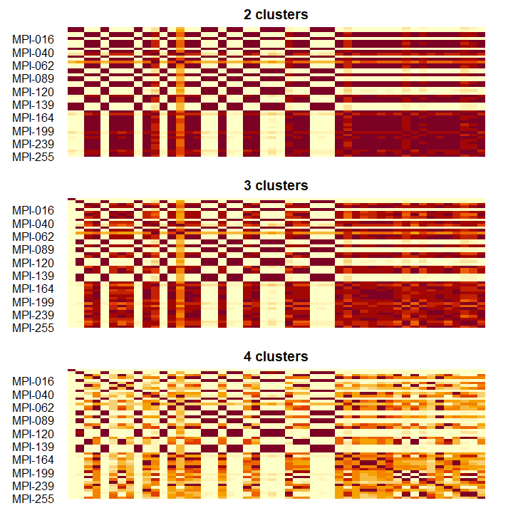

```r
> consensus_list <- list()
> toggle_list <- list()
> clusters_max <- 4
> par(mar=c(1,5,2,2))
> par(mfrow=c(clusters_max-1,1))
>
> for (i in 2:clusters_max){
+   results <- consensus(myData, k_clusters=i, k_run=100)
+   consensus_list[[i-1]] <- results[[1]]
+   toggle_list[[i-1]] <- results[[2]]
+
+   image(1:ncol(results[[1]]), 1:nrow(results[[1]]), t(results[[1]])[,nrow(results[[1]]):1], axes=FALSE, xlab="", ylab="", main=paste(toString(i), "clusters"))
+   axis(2, at = 1:nrow(results[[1]]), labels=rev(rownames(results[[1]])),las=2,tick=FALSE)
+ }
```

**Answer (4a):** Stabile Proben sind durch die beiden Extremen Enden des Farbspektrums gekennzeichnet. In diesem Fall sind das rot und weiß. Unstabile Proben sind demnach orange gefärbt.

```r
> toggle_2 <- toggle_list[[1]] #2 cluster
> unstable_2 <- which(toggle_2 > 0.30)
> rownames(consensus_list[[1]])[unstable_2]
```

```
## [1] "MPI-051"
```

```r
> sample_dist <- dist(t(myData))
> sample_hclust <- hclust(sample_dist, method = "complete")
> clusters <- cutree(sample_hclust, 2)
> myPheno <- pData(mmml.subset)
>
> table(clusters, myPheno$GCBABC)
```

```
##
## clusters ABC GCB
##        1   0  15
##        2  25  10
```

```r
> table(clusters, myPheno$GENDER)
```

```
##
## clusters    female male
##        1  0      2   13
##        2  0     15   20
```

```r
> cut_ages <- cut(myPheno$AGE, breaks=seq(0,100,10), right = FALSE)
> table(cut_ages, clusters)
```

```
##           clusters
## cut_ages    1  2
##   [0,10)    5  1
##   [10,20)   2  0
##   [20,30)   2  1
##   [30,40)   1  1
##   [40,50)   3  3
##   [50,60)   1  3
##   [60,70)   1 13
##   [70,80)   0 12
##   [80,90)   0  1
##   [90,100)  0  0
```